# AEON MERX CURSOS - METODOLOGÍA B.I.O.S

# TENSOR FLOW

ANTES DE METERNOS EN TENSORES E INTELIGENCIA ARTIFICIAL, REPASEMOS LO QUE HACE MATPLOTLIB PARA VISUALIZAR GRÁFICOS EN ESTE EJEMPLO REALIZAREMOS UN GRÁFICO DE LA FUNCIÓN SENO

1. SE IMPORTAN LAS BIBLIOTECAS MATPLOTLIB Y NUMPY
2. LUEGO SE CREA UNA VARIABLE X USANDO LA FUNCIÓN ARANGE() DE NUMPY LA FUNCIÓN DEVUELVE UN ARREGLO DE VALORES QUE COIENZAN EN 0 Y TERMINA EN 10, AVANZANDO DE 0.1 EN 0.1 EL ARREGLO DE ALMACENA EN LA VARIABLE X
3. SE CREA UNA VARIABLE Y QUE CONTIENE LOS VALORES DEL SENO DE CADA ELEMENTO DE X, ESTO SE LOGRA USADO LA FUNCIÓN SIN() DE NUMPY
4. LUEGO SE UTILIZA LA FUNCIÓN PLOT DE MATPLOTLIB PARA TRAZAR LOS VALORES DE "X" Y "Y" EN UN GRÁFICO
5. FINALMENTE SE MUESTRA EL GRÁFICO UTILIZANDO LA FUNCIÓN SHOW DE MATPLOTLIB

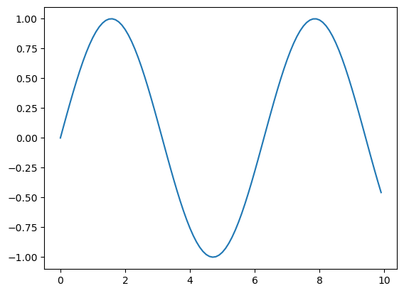

```python
import matplotlib.pyplot as plt
import numpy as np
x = np.arange(0,10,0.1)
y = np.sin(x)
plt.plot(x,y)
plt.show()
```

TENSOR FLOW ES UNA BIBLIOTECA DE CÓDIGO ABIERTO DESARROLLADA POR GOOGLE SE UTILIZA PRINCIPALMENTE PARA CONSTRUIR Y ENTRENAR MODELOS DE APRENDIZAJE AUTOMÁTICO Y REDES NEURONALES.

TENSOR FLOW ESTÁ DISEÑADO PARA FUNCIONAR CON DATOS EN FORMA DE ARREGLOS MULTIDIMENSIONALES(TENSORES) LO QUE FACILITA LA MANIPULACIÓN Y EL PROCESAMIENTO DE DATOS PARA EL APRENDIZAJE AUTOMÁTICO LA BIBLIOTECA OFRECE HERRAMIENTAS PARA CREAR Y ENTRENAR MODELOS DE APRENDIZAJE AUTOMÁTICO.

LA BIBLIOTECA OFRECE HERRAMIENTAS PARA CREAR Y ENTRENAR MODELOS DE APRENDIZAJE PROFUNDO, DESDE MODELOS DE REDES NEURONALES SIMPLES HASTA ARQUITECTURAS MÁS COMPLEJAS COMO CONVOLUCIONES LSTM Y REDES NEURONALES RECURRENTES.

[figure not shown]

TENSOR FLOW ES ALTAMENTE ESCALABLE Y SE PUEDE EJECUTAR EN DIFERENTES TIPOS DE DISPOSITIVOS COMO **CPU, GPU Y TPU** ADEMÁS TENSORFLOW OFRECE UNA AMPLIA GAMA DE HERRAMIENTAS Y UTILIDADES QUE FACILITAN ELD ESARROLLO Y LA DEPURACIÓN DE MODELOS, INCLUIDOS TENSORBOARD PARA VISUALIZAR EL RENDIMIENTO DE LOS MODELOS.

**TENSOR FLOW HUB** PARA COMPARTIR Y REUTILIZAR MODELOS PRE-ENTRENADOS Y **TENSORFLOW LITE** PARA IMPLEMENTAR MODELOS EN DISPOSITIVOS MÓVILES Y DISPOSTIVOS DE BORDE. EN RESUMEN TENSORFLOW ES UNA BIBLIOTECA DE APRENDIZAJE AUTOMÁTICO ALTAMENTE FLEXIBLE , ESCALABLE Y PODEROSA QUE PERMITE A LOS DESARROLLADORES Y CIENTÍFICOS DE DATOS CONSTRUIR, ENTRENAR Y DESPLEGAR MODELOS DE APRENDIZAJE AUTOMÁTICO DE MANERA EFICIENTE Y EFECTIVA.

## PARTES PRINCIPALES DE UNA RED NEURONAL ARTIFICIAL

[figure not shown]

### CREAR UN TENSOR

```python
import tensorflow as tf
import numpy as np
#CREAR UN TENSOR DE RANGO 0 (ESCALAR)
tensor_escalar = tf.constant(5)
# CREAR UN TENSOR DE RANGO 1 (VECTOR)
tensor_vector = tf.constant([1,2,3,4,5,6])
# CREAR UN TENSOR DE RANGO 2 (MATRIZ)
tensor_matriz = tf.constant([[1,2],[3,4]])
print("Tensor escalar: ",tensor_escalar)
print("Tensor vector: ",tensor_vector)
print("Tensor matriz: ",tensor_matriz)
```

```
Tensor escalar:  tf.Tensor(5, shape=(), dtype=int32)
Tensor vector:  tf.Tensor([1 2 3 4 5 6], shape=(6,), dtype=int32)
Tensor matriz:  tf.Tensor(
[[1 2]
 [3 4]], shape=(2, 2), dtype=int32)
```

### OPERACIONES BÁSICAS DE UN TENSOR

```python
import tensorflow as tf
# EL TENSOR 1 REPRESENTA LAS LETRAS ABC EN EL CÓDIGO AEON MERX
tensor1 = tf.constant([693,396,111])
# EL TENSOR 2 REPRESENTA LAS LETRAS DEF EN EL CÓDIGO AEON MERX
tensor2 = tf.constant([714,417,222])

#SUMA
suma = tf.add(tensor1,tensor2)
# MULTIPLICACIÓN
producto = tf.multiply(tensor1,tensor2)
# DIVISIÓN
cociente = tf.divide(tensor1,tensor2)
print("Suma: ", suma )
print("Producto: ", producto)
print("Cociente: ", cociente )
```

```
Suma:  tf.Tensor([1407  813  333], shape=(3,), dtype=int32)
Producto:  tf.Tensor([494802 165132  24642], shape=(3,), dtype=int32)
Cociente:  tf.Tensor([0.97058824 0.94964029 0.5       ], shape=(3,), dtype=float64)
```

### CREAR UN MODELO DE RED NEURONAL BÁSICO

```python
import tensorflow as tf
# definir modelo secuencial
model = tf.keras.models.Sequential()

#Agregar capa densa con 64 neuronas, activación ReLU y entada de 784 caracterízticas
model.add(tf.keras.layers.Dense(64,activation='relu',input_shape=(784,)))

#Agregar capa de salida con 10 neuronas y activación softmax
model.add(tf.keras.layers.Dense(10,activation='softmax'))

#Compilar modelo con función de perdida 'categorical_crossentropy',optimizador 'adam' y métrica de precisión
model.compile(loss='categorical_crossentropy', optimizer='adam',metrics=['accuracy'])
```

###### SI QUEREMOS VER LA ARQUITECTURA DEL MODELO

```python
model.summary()
```

```
Model: "sequential_1"
_________________________________________________________________
 Layer (type)                Output Shape              Param #
=================================================================
 dense_2 (Dense)             (None, 64)                50240

 dense_3 (Dense)             (None, 10)                650

=================================================================
Total params: 50,890
Trainable params: 50,890
Non-trainable params: 0
_________________________________________________________________
```

###### AHORA VAMOS A CREAR VARIAS REDES NEURONALES UTILIZANDO TENSORLFOW Y VISUALIZAR LOS RESULTADOS CON MATPLOTLIB

## MÁS EJEMPLOS DE TENSORES

```python
import tensorflow as tf
tensor = tf.constant([[1,2,3],[4,5,6],[7,8,9]])
print(tensor)
```

```
tf.Tensor(
[[1 2 3]
 [4 5 6]
 [7 8 9]], shape=(3, 3), dtype=int32)
```

```python
tensor_4d = tf.ones((5,4,3,2))
print(tensor_4d)
```

```
tf.Tensor(
[[[[1. 1.]
   [1. 1.]
   [1. 1.]]

  [[1. 1.]
   [1. 1.]
   [1. 1.]]

  [[1. 1.]
   [1. 1.]
   [1. 1.]]

  [[1. 1.]
   [1. 1.]
   [1. 1.]]]


 [[[1. 1.]
   [1. 1.]
   [1. 1.]]

  [[1. 1.]
   [1. 1.]
   [1. 1.]]

  [[1. 1.]
   [1. 1.]
   [1. 1.]]

  [[1. 1.]
   [1. 1.]
   [1. 1.]]]


 [[[1. 1.]
   [1. 1.]
   [1. 1.]]

  [[1. 1.]
```

[output cut: 29 more lines]

```
 [[[1. 1.]
   [1. 1.]
   [1. 1.]]

  [[1. 1.]
   [1. 1.]
   [1. 1.]]

  [[1. 1.]
   [1. 1.]
   [1. 1.]]

  [[1. 1.]
   [1. 1.]
   [1. 1.]]]], shape=(5, 4, 3, 2), dtype=float32)
```

```python
import tensorflow as tf
shape = tf.constant([3,4])
tensor = tf.zeros(shape)
print(tensor)
```

```
tf.Tensor(
[[0. 0. 0. 0.]
 [0. 0. 0. 0.]
 [0. 0. 0. 0.]], shape=(3, 4), dtype=float32)
```

### PREDICCIÓN DECENTÍGRADOS A FAHRENHEIT

```
Comenzando entrenamiento
Modelo entrenado!
```

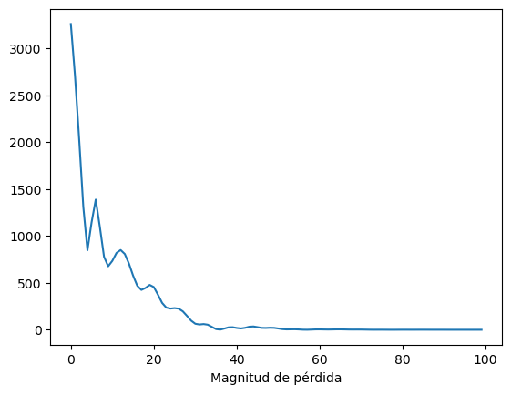

```python
import tensorflow as tf
import numpy as np
celsius = np.array([-40,-10,0,8,15,22,38], dtype=float)
fahrenheit = np.array([-40,14,32,46,59,72,100], dtype=float)

#capa = tf.keras.layers.Dense(units=1,input_shape=[1])
#modelo = tf.keras.Sequential([capa])
oculta1 = tf.keras.layers.Dense(units=3,input_shape=[1])
oculta2 = tf.keras.layers.Dense(units=3)
salida = tf.keras.layers.Dense(units=1)
#-------------------------------------------------------------
modelo = tf.keras.Sequential([oculta1,oculta2,salida])

modelo.compile(
    optimizer=tf.keras.optimizers.Adam(0.1),
    loss='mean_squared_error'
)
print("Comenzando entrenamiento")

print("Modelo entrenado!")

import matplotlib.pyplot as plt
historial = modelo.fit(celsius,fahrenheit,epochs=100,verbose=False)
plt.xlabel("# Epoca")
plt.xlabel("Magnitud de pérdida")
plt.plot(historial.history["loss"])
```

```python
print("Hacer una predicción")
resultado = modelo.predict([100.0])
print("El resultado es"+str(resultado)+"fahrenheit!")
```

```
Hacer una predicción
El resultado es[[211.18726]]fahrenheit!
```

```python
print("Variable internas del modelo")
#print(capa.get_weights())
print(oculta1.get_weights())
print(oculta2.get_weights())
print(salida.get_weights())
```

```
Variable internas del modelo
[array([[ 0.22633241, -0.32311615,  0.37191767]], dtype=float32), array([ 3.2993677, -3.502383 ,  3.5333996], dtype=float32)]
[array([[-0.08524732, -1.1183635 ,  0.74609905],
       [-0.46843103,  1.2691892 , -0.42211732],
       [ 0.60619307, -1.1802814 ,  0.37879792]], dtype=float32), array([ 2.3182988, -3.5897593,  3.503185 ], dtype=float32)]
[array([[ 0.46154568],
       [-1.0957879 ],
       [ 0.94614404]], dtype=float32), array([3.2861795], dtype=float32)]
```

# REGRESIÓN LINEAL

En este ejemplo, estamos creando datos de ejemplo utilizando la función numpy.random.rand() y la función numpy.random.randn(). Luego, estamos creando cinco modelos secuenciales utilizando TensorFlow, cada uno con una capa densa de una sola neurona y una activación lineal. Después de compilar cada modelo, los agregamos a una lista llamada models.

Luego, estamos entrenando cada modelo en la lista models utilizando los datos de entrenamiento X e y durante 20 épocas. Finalmente, estamos visualizando los resultados utilizando la biblioteca Matplotlib. Cada modelo se muestra en la gráfica como una línea de color diferente, y los datos de entrenamiento se muestran como puntos azules.

Este es solo un ejemplo básico de cómo crear y visualizar varios modelos de redes neuronales utilizando TensorFlow y Matplotlib. Por supuesto, hay muchas variaciones y personalizaciones que se pueden agregar, dependiendo del problema que estés tratando de resolver.

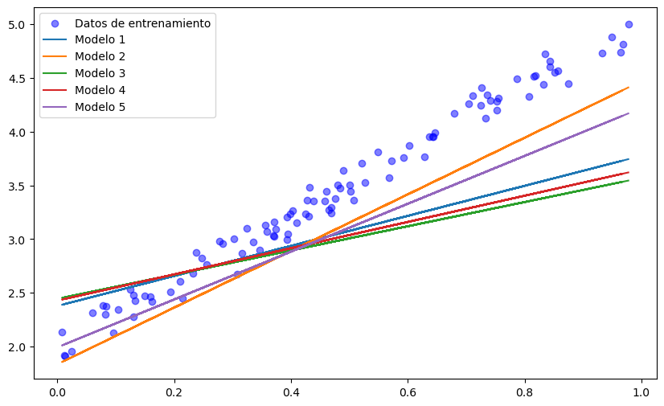

```python
import tensorflow as tf
import numpy as np
import matplotlib.pyplot as plt

# Crear datos de ejemplo
X = np.random.rand(100, 1)
y = 3 * X + 2 + np.random.randn(100, 1) * 0.1

# Crear modelos secuenciales
models = []
for i in range(5):
    model = tf.keras.models.Sequential()
    model.add(tf.keras.layers.Dense(1, input_shape=(1,), activation='linear'))
    model.compile(optimizer='sgd', loss='mse')
    models.append(model)

# Entrenar modelos
epochs = 20
for model in models:
    history = model.fit(X, y, epochs=epochs, verbose=0)

# Visualizar resultados
plt.figure(figsize=(10, 6))
plt.scatter(X, y, c='b', alpha=0.5, label='Datos de entrenamiento')
for i, model in enumerate(models):
    y_pred = model.predict(X)
    plt.plot(X, y_pred, label='Modelo {}'.format(i+1))
plt.legend()
plt.show()
```

El ejemplo que proporcioné es una versión simplificada de una regresión lineal. En la vida real, la regresión lineal es una técnica común utilizada en el análisis de datos y el aprendizaje automático para predecir valores continuos a partir de un conjunto de datos. Por ejemplo, si tienes datos de ventas de una empresa en función del tiempo, puedes utilizar una regresión lineal para predecir las ventas futuras en función del tiempo.

El código que proporcioné puede ser útil para entender cómo funcionan las redes neuronales en la regresión lineal y cómo entrenar múltiples modelos para realizar esta tarea. También puede ser útil para entender cómo visualizar los resultados de los modelos utilizando Matplotlib.

En general, la regresión lineal es solo un ejemplo de las muchas aplicaciones prácticas que tienen las redes neuronales en la vida real, desde la visión por computadora y el procesamiento del lenguaje natural hasta la robótica y la automatización industrial.

## CREANDO UNA RED NEURONAL: TENSOR FLOW VS PYTORCH

### TENSORFLOW

```python
import tensorflow as tf

# Cargar datos de MNIST
(x_train, y_train), (x_test, y_test) = tf.keras.datasets.mnist.load_data()

# Preprocesamiento de datos
x_train = x_train.reshape(-1, 28 * 28).astype("float32") / 255.0
x_test = x_test.reshape(-1, 28 * 28).astype("float32") / 255.0
y_train = tf.keras.utils.to_categorical(y_train.astype("float32"))
y_test = tf.keras.utils.to_categorical(y_test.astype("float32"))

# Definir modelo de red neuronal
model = tf.keras.models.Sequential([
    tf.keras.layers.Dense(256, activation='relu', input_shape=(28 * 28,)),
    tf.keras.layers.Dropout(0.2),
    tf.keras.layers.Dense(10, activation='softmax')
])

# Compilar modelo
model.compile(optimizer='adam', loss='categorical_crossentropy', metrics=['accuracy'])

# Entrenar modelo
model.fit(x_train, y_train, epochs=10, validation_data=(x_test, y_test))
```

```
<keras.callbacks.History at 0x21a2f09e0b0>
```

```python
model.summary()
```

```
Model: "sequential_8"
_________________________________________________________________
 Layer (type)                Output Shape              Param #
=================================================================
 dense_12 (Dense)            (None, 256)               200960

 dropout (Dropout)           (None, 256)               0

 dense_13 (Dense)            (None, 10)                2570

=================================================================
Total params: 203,530
Trainable params: 203,530
Non-trainable params: 0
_________________________________________________________________
```

Para crear un tensor que simule un cromosoma del ADN podemos utilizar la función np.random.choice() de NumPy para generar una secuencia aleatoria de nucleótidos (A, C, G, T) de una longitud determinada. Luego, podemos representar cada nucleótido como un número entero utilizando un diccionario y convertir la secuencia en un tensor de NumPy. Aquí tienes un ejemplo:

```python
import numpy as np

# Longitud del cromosoma
length = 1000

# Generar secuencia aleatoria de nucleótidos
nucleotides = ['A', 'C', 'G', 'T']
sequence = np.random.choice(nucleotides, size=length)

# Diccionario para convertir nucleótidos a números enteros
nucleotide_to_int = {'A': 0, 'C': 1, 'G': 2, 'T': 3}

# Convertir secuencia de nucleótidos en un tensor de NumPy
tensor = np.array([nucleotide_to_int[n] for n in sequence])

# Mostrar tensor
print(tensor)
```

```
[1 1 0 2 0 1 0 2 3 0 1 3 0 3 2 0 0 1 2 0 2 0 2 0 1 0 2 3 1 1 2 3 2 1 3 1 1
 2 1 2 1 3 3 2 1 3 3 3 0 2 3 2 2 0 1 2 2 3 0 2 1 3 2 1 3 2 1 0 1 2 1 0 3 1
 2 1 3 0 3 1 1 3 2 3 3 2 2 3 2 2 3 2 0 0 2 0 3 2 1 2 0 2 0 1 1 2 1 3 0 3 2
 0 3 2 3 1 1 0 1 2 3 2 2 1 2 3 2 0 0 3 1 0 3 2 3 2 0 0 2 0 1 0 0 2 1 1 0 1
 1 3 1 3 3 1 0 1 2 0 3 3 3 3 1 1 3 3 1 1 0 2 0 1 2 1 0 3 2 2 3 1 2 2 1 1 3
 2 3 0 0 3 2 2 3 0 2 2 1 3 0 1 1 1 3 1 1 2 1 2 3 0 2 2 1 1 0 1 0 2 2 2 1 2
 1 2 2 3 1 3 3 2 3 2 1 0 0 0 0 2 3 3 0 2 1 2 3 3 1 3 1 2 1 2 0 2 0 3 2 3 0
 1 0 0 0 2 3 0 2 0 0 0 0 2 1 1 3 1 3 2 3 3 0 1 3 1 1 0 1 3 1 3 2 0 0 2 0 3
 3 3 3 2 2 0 3 1 2 1 3 3 0 0 1 3 2 3 2 1 3 1 0 3 1 0 2 1 1 1 1 1 2 1 2 1 0
 0 3 2 3 1 3 0 2 2 1 0 0 1 3 0 0 1 0 0 2 2 3 3 3 3 2 0 1 1 1 0 1 3 2 3 3 3
 0 2 3 2 0 1 1 3 3 2 0 0 2 0 2 1 1 2 2 2 1 1 3 2 3 1 2 1 1 2 1 2 3 2 3 1 0
 2 2 2 0 3 3 0 3 2 3 3 1 2 0 2 3 1 0 1 1 0 0 3 1 0 1 1 1 3 2 2 3 2 2 3 1 0
 3 1 1 1 2 2 3 1 0 3 3 3 0 2 2 0 2 2 0 0 0 0 0 2 0 2 3 3 0 3 3 2 1 0 0 1 3
 0 1 2 2 3 1 0 3 0 1 0 1 3 1 3 1 0 3 0 1 3 2 1 3 0 3 0 1 2 2 1 2 1 1 0 1 0
 1 3 0 0 2 3 3 0 2 2 0 1 0 2 3 0 2 0 3 0 1 2 0 0 2 3 2 2 1 0 2 2 0 3 0 2 0
 2 1 1 0 3 0 3 0 1 3 0 2 2 3 3 3 3 3 3 2 1 0 0 0 2 0 0 0 3 1 0 2 2 0 0 2 2
 3 0 0 2 3 0 0 2 3 2 2 0 0 3 2 1 0 0 0 1 3 0 3 1 2 2 0 0 2 1 2 2 2 0 1 1 2
 3 0 1 2 2 0 0 2 0 0 0 3 3 0 2 0 3 2 2 3 3 3 0 1 2 2 3 3 3 0 3 2 0 1 1 0 3
 2 3 2 2 3 3 1 2 3 1 3 2 0 0 2 1 3 1 3 0 3 3 3 1 2 0 2 2 2 1 1 3 1 2 2 1 3
 1 1 2 3 2 0 2 3 2 2 0 3 2 3 2 3 2 3 3 1 3 2 0 0 2 3 0 3 3 0 3 0 0 2 1 3 3
 0 3 1 1 0 1 0 0 1 1 3 0 3 0 2 3 2 3 3 1 1 1 3 0 1 2 3 2 0 3 2 1 0 3 1 0 1
 0 0 3 0 0 0 2 1 1 2 2 1 3 0 2 1 3 2 1 1 1 0 1 1 1 1 1 2 2 3 3 1 3 2 2 1 0
 1 2 0 2 1 3 0 1 1 3 0 3 0 2 1 0 2 0 2 0 2 3 3 3 2 3 0 0 1 0 2 1 2 2 3 0 2
 2 0 1 2 2 3 2 1 2 3 2 3 0 3 0 1 3 2 0 2 1 3 0 1 3 2 1 1 1 3 3 3 2 1 2 0 1
 3 1 0 1 3 2 0 3 1 0 2 0 1 2 0 1 0 3 1 0 2 0 2 2 0 2 3 1 0 0 2 2 3 1 2 2 0
 3 0 1 0 3 2 2 3 0 3 3 2 1 0 3 1 2 3 0 3 3 2 3 3 2 0 0 3 3 2 3 0 3 1 3 2 1
 2 1 1 1 0 0 3 1 2 2 1 0 0 1 0 3 2 3 0 1 2 3 2 3 1 0 3 2 3 3 2 2 3 3 1 3 0
 1]
```

Este código genera una secuencia aleatoria de nucleótidos de longitud 1000 y la convierte en un tensor de NumPy donde cada nucleótido está representado como un número entero. El resultado será un tensor unidimensional de forma (1000,).

### PYTORCH

```python
import torch
import torch.nn as nn

# Definir la clase para la red neuronal
class SimpleNet(nn.Module):
    def __init__(self):
        super(SimpleNet, self).__init__()
        self.layer1 = nn.Linear(2, 5)
        self.layer2 = nn.Linear(5, 1)

    def forward(self, x):
        x = torch.relu(self.layer1(x))
        x = self.layer2(x)
        return x

# Definir la entrada
input_tensor = torch.tensor([[1.0, 2.0], [2.0, 3.0]])

# Instanciar la red neuronal
net = SimpleNet()

# Realizar la inferencia
output_tensor = net(input_tensor)

# Imprimir la salida
print(output_tensor)
```

```
tensor([[0.3754],
        [0.1620]], grad_fn=<AddmmBackward0>)
```

```python
import torch
import torch.nn as nn
import torch.optim as optim
import torchvision.transforms as transforms
import torchvision.datasets as datasets
import torchvision.models as models
```

```python
#DEFINIR TRANSFORMACIONES PARA LOS DATOS
transform_train = transforms.Compose([
    transforms.RandomHorizontalFlip(),
    transforms.RandomCrop(32, padding=4),
    transforms.ToTensor(),
    transforms.Normalize(mean=[0.485, 0.456, 0.406], std=[0.229, 0.224, 0.225])
])

transform_test = transforms.Compose([
    transforms.ToTensor(),
    transforms.Normalize(mean=[0.485, 0.456, 0.406], std=[0.229, 0.224, 0.225])
])
```

```python
#CARGAR UN PEQUEÑO CONJUNTO DE DATOS
train_dataset = datasets.CIFAR10(root='./data', train=True, download=True, transform=transform_train)
test_dataset = datasets.CIFAR10(root='./data', train=False, download=True, transform=transform_test)

train_dataset = torch.utils.data.Subset(train_dataset, range(100))
test_dataset = torch.utils.data.Subset(test_dataset, range(50))

train_loader = torch.utils.data.DataLoader(train_dataset, batch_size=10, shuffle=True, num_workers=2)
test_loader = torch.utils.data.DataLoader(test_dataset, batch_size=10, shuffle=False, num_workers=2)
```

```
Files already downloaded and verified
Files already downloaded and verified
```

```python
#DEFINIR EL MODELO ResNet34 PRE-ENTRENADO
model = models.resnet34(pretrained=True)
num_features = model.fc.in_features
model.fc = nn.Linear(num_features, 10)
```

```python
# DEFINIR LA FUNCIÓN DE PERDIDA Y EL OPTIMIZADOR
criterion = nn.CrossEntropyLoss()
optimizer = optim.SGD(model.parameters(), lr=0.001, momentum=0.9)
```

```python
#ENTRENAR EL MODELO
for epoch in range(10):
    running_loss = 0.0
    for i, data in enumerate(train_loader, 0):
        inputs, labels = data

        optimizer.zero_grad()

        outputs = model(inputs)
        loss = criterion(outputs, labels)
        loss.backward()
        optimizer.step()

        running_loss += loss.item()

        if i % 10 == 9:
            print('[%d, %5d] loss: %.3f' % (epoch + 1, i + 1, running_loss / 10))
            running_loss = 0.0

print('Entrenamiento completado')
```

```
[1,    10] loss: 2.586
[2,    10] loss: 2.222
[3,    10] loss: 1.905
[4,    10] loss: 1.906
[5,    10] loss: 1.935
[6,    10] loss: 1.696
[7,    10] loss: 1.511
[8,    10] loss: 1.417
[9,    10] loss: 1.289
[10,    10] loss: 1.290
Entrenamiento completado
```

TensorFlow es una biblioteca de aprendizaje automático de propósito general desarrollada por Google que es ampliamente utilizada en la industria y la investigación. Es conocido por su flexibilidad y escalabilidad, lo que lo hace adecuado para proyectos grandes y complejos. TensorFlow tiene una amplia gama de herramientas y funcionalidades, incluidas las capacidades de distribución y la integración con otras herramientas de Google, como TensorBoard y TFX.

Por otro lado, PyTorch es una biblioteca de aprendizaje automático de código abierto desarrollada por Facebook que es popular en la investigación debido a su facilidad de uso y flexibilidad. PyTorch permite un flujo de trabajo intuitivo y una depuración más fácil, lo que lo hace ideal para proyectos más pequeños o para aquellos que se centran en la investigación y la experimentación. PyTorch también tiene una comunidad activa y una amplia gama de recursos de aprendizaje y tutoriales.

En resumen, ambas bibliotecas tienen sus fortalezas y debilidades, y la elección depende de las necesidades y preferencias específicas de cada proyecto.

#### MÁS DE TENSORFLOW...

Una red neuronal en TensorFlow en Python para analizar datos de ADN utilizando las bases nitrogenadas Guanina, Citosina, Adenina y Timina:

Este código crea una red neuronal con una arquitectura de dos capas ocultas de 64 neuronas cada una y una capa de salida con una función de activación sigmoidal. La red neuronal se compila con la función de pérdida "binary_crossentropy" y el optimizador "adam". El modelo se entrena con los datos de ejemplo y se evalúa con el conjunto de datos de prueba.

Es importante tener en cuenta que este es solo un ejemplo básico y que para crear una red neuronal para analizar datos de ADN de manera precisa y efectiva, se requiere una gran cantidad de datos y un conocimiento profundo de la bioinformática y la genética.

```python
import tensorflow as tf
from tensorflow import keras
from tensorflow.keras import layers

# Definir los datos de ejemplo
data = [
    "GCTAGATCGA",
    "ATCGTACCGT",
    "CGATTACCGT",
    "CGTACCGTAC",
    "CGTACCGTAA",
    "CGTACCGTAG",
    "CGTACCGTAT",
    "CGTACCGTAC",
    "CGTACCGTAA",
    "CGTACCGTAG",
]

# Definir el diccionario que mapea las bases nitrogenadas a valores numéricos
base_map = {"G": 0, "C": 1, "A": 2, "T": 3}

# Convertir los datos de ejemplo a valores numéricos
x_data = []
for sequence in data:
    x_data.append([base_map[base] for base in sequence])

# Convertir los valores numéricos a un array de numpy
import numpy as np
x_data = np.array(x_data)

# Definir las etiquetas de ejemplo
y_data = np.array([1, 0, 0, 1, 1, 0, 1, 1, 1, 0])

# Definir la arquitectura de la red neuronal
model = keras.Sequential([
    layers.Dense(64, activation="relu", input_shape=(10,)),
    layers.Dense(64, activation="relu"),
    layers.Dense(1, activation="sigmoid")
])

# Compilar el modelo con la función de pérdida y el optimizador
model.compile(loss="binary_crossentropy", optimizer="adam", metrics=["accuracy"])

# Entrenar el modelo
model.fit(x_data, y_data, epochs=10, batch_size=1)

# Evaluar el modelo
test_data = [
    "GCTAGATCGA",
    "ATCGTACCGT",
    "CGATTACCGT",
    "CGTACCGTAC",
    "CGTACCGTAA",
    "CGTACCGTAG",
    "CGTACCGTAT",
    "CGTACCGTAC",
    "CGTACCGTAA",
    "CGTACCGTAG",
]
x_test = []
for sequence in test_data:
    x_test.append([base_map[base] for base in sequence])
x_test = np.array(x_test)
y_pred = model.predict(x_test)
print(y_pred)
```

```
[[0.8054626 ]
 [0.0888257 ]
 [0.33646917]
 [0.6759959 ]
 [0.82928735]
 [0.47196075]
 [0.8878059 ]
 [0.6759959 ]
 [0.82928735]
 [0.47196075]]
```

El ejemplo anterior de una red neuronal en TensorFlow para analizar datos de ADN podría tener varias aplicaciones en la vida real y en la investigación científica, por ejemplo:

Clasificación de secuencias de ADN: la red neuronal puede ser entrenada para identificar patrones en las secuencias de ADN y clasificarlas en diferentes categorías, como por ejemplo, identificar si una secuencia pertenece a un gen o a una región no codificante del ADN. Esto podría ser útil en la investigación biomédica para identificar genes relacionados con enfermedades o para entender mejor la evolución del ADN.

Diagnóstico de enfermedades genéticas: la red neuronal podría ser utilizada para analizar secuencias de ADN de pacientes y detectar mutaciones asociadas con enfermedades genéticas. Esto podría ayudar a los médicos a diagnosticar y tratar enfermedades genéticas de manera más precisa y temprana.

Análisis de secuencias de ARN: además de analizar secuencias de ADN, la red neuronal podría ser entrenada para analizar secuencias de ARN, lo que podría ser útil en la investigación de enfermedades como el cáncer, donde las mutaciones en el ARN pueden ser un indicador de la presencia de la enfermedad.

En general, el análisis de secuencias de ADN y ARN es un área de gran interés en la investigación biomédica y la biotecnología, y las redes neuronales pueden ser una herramienta útil para analizar y clasificar grandes cantidades de datos de secuencias de manera efectiva y precisa.

La impresión que se muestra es una matriz de dimensiones 10x1. Cada fila de la matriz contiene un valor numérico entre 0 y 1. Estos valores pueden ser interpretados como las probabilidades de que una determinada muestra de datos pertenezca a una clase específica en un problema de clasificación.

Por ejemplo, la red neuronal podría ser entrenada para clasificar secuencias de ADN de pacientes en función de su predisposición genética a cierta enfermedad, como cáncer de mama. En este caso, la salida de la red neuronal podría ser una probabilidad para cada paciente, donde una probabilidad alta (cerca de 1) indicaría una mayor predisposición genética a la enfermedad, mientras que una probabilidad baja (cerca de 0) indicaría una menor predisposición.

En resumen, la impresión podría representar la salida de la red neuronal entrenada para clasificar diferentes secuencias de ADN en función de su relación con una enfermedad o característica específica. Cada fila de la matriz representa la probabilidad de que una determinada secuencia de ADN esté relacionada con la enfermedad o característica específica.

```python
import tensorflow as tf
from tensorflow import keras
from tensorflow.keras import layers

# Definir los datos de ejemplo
dna_data = [
    "GCTAGATCGA",
    "ATCGTACCGT",
    "CGATTACCGT",
    "CGTACCGTAC",
    "CGTACCGTAA",
    "CGTACCGTAG",
    "CGTACCGTAT",
    "CGTACCGTAC",
    "CGTACCGTAA",
    "CGTACCGTAG",
]

# Definir las etiquetas de ejemplo
protein_data = np.array(["L", "V", "A", "G", "R", "I", "D", "G", "R", "I"])

# Definir el diccionario que mapea las bases nitrogenadas a valores numéricos
dna_map = {"G": 0, "C": 1, "A": 2, "T": 3}

# Convertir los datos de ADN de ejemplo a valores numéricos
x_data = []
for sequence in dna_data:
    x_data.append([dna_map[base] for base in sequence])

# Convertir los valores numéricos a un array de numpy
import numpy as np
x_data = np.array(x_data)

# Definir la arquitectura de la red neuronal
model = keras.Sequential([
    layers.Dense(64, activation="relu", input_shape=(10,)),
    layers.Dense(64, activation="relu"),
    layers.Dense(7, activation="softmax")
])

# Compilar el modelo con la función de pérdida y el optimizador
model.compile(loss="categorical_crossentropy", optimizer="adam", metrics=["accuracy"])

# Convertir las etiquetas de proteínas a valores numéricos y aplicar codificación one-hot
from sklearn.preprocessing import LabelEncoder
from keras.utils import to_categorical

le = LabelEncoder()
protein_data_encoded = le.fit_transform(protein_data)
protein_data_encoded = to_categorical(protein_data_encoded)

# Entrenar el modelo
model.fit(x_data, protein_data_encoded, epochs=10, batch_size=1)

# Evaluar el modelo
test_dna_data = [
    "CGTACCGTAG",
    "CGTACCGTAC",
    "GCTAGATCGA",
    "ATCGTACCGT",
    "CGATTACCGT",
    "CGTACCGTAC",
    "CGTACCGTAA",
    "CGTACCGTAG",
    "CGTACCGTAA",
    "CGTACCGTAT",
]
x_test_data = []
for sequence in test_dna_data:
    x_test_data.append([dna_map[base] for base in sequence])
x_test_data = np.array(x_test_data)

# Realizar predicciones en los datos de prueba
predictions = model.predict(x_test_data)

# Convertir las predicciones a etiquetas de proteínas
predicted_protein_data_encoded = np.argmax(predictions, axis=1)
predicted_protein_data = le.inverse_transform(predicted_protein_data_encoded)

print(predicted_protein_data)
```

```
WARNING:tensorflow:5 out of the last 14 calls to <function Model.make_predict_function.<locals>.predict_function at 0x0000021A3467B2E0> triggered tf.function retracing. Tracing is expensive and the excessive number of tracings could be due to (1) creating @tf.function repeatedly in a loop, (2) passi…
['I' 'I' 'L' 'V' 'A' 'I' 'R' 'I' 'R' 'R']
```

Cuando vemos una secuencia de ADN como "GCTAGATCGA", las letras G, C, A, y T representan las diferentes moléculas que forman el ADN. Cada una de estas letras es una base nitrogenada que puede unirse a otra base nitrogenada. Sin embargo, cuando se trabaja con redes neuronales, no es práctico trabajar directamente con letras o moléculas.

En su lugar, podemos asignar un número a cada base nitrogenada, de modo que G se convierta en 0, C en 1, A en 2, y T en 3. De esta manera, podemos representar cada secuencia de ADN como una lista de números en lugar de letras o moléculas.

En el ejemplo que viste, se convierten las secuencias de ADN en números utilizando un diccionario que asigna a cada letra un número correspondiente. Luego, estos números se utilizan como entrada para la red neuronal.

Es importante tener en cuenta que la red neuronal no "entiende" lo que significan estos números, simplemente los usa para hacer predicciones. En este caso, la red neuronal trata de predecir qué proteína se producirá a partir de cada secuencia de ADN.

Después de que la red neuronal hace sus predicciones, los números se convierten de vuelta a letras utilizando otro proceso similar al que se usó para convertir letras en números. Esto nos da las etiquetas de proteína que podemos leer y entender como "I", "L", "V", etc.

Claro, aquí te presento un ejemplo de cómo se puede utilizar TensorFlow para simular un problema de trading utilizando una red neuronal.

El objetivo de este ejemplo es entrenar una red neuronal para predecir el precio futuro de una acción utilizando datos históricos de precios y otros indicadores técnicos.

Primero, es importante mencionar que el trading en los mercados financieros es un problema muy complejo y que no se puede garantizar que la red neuronal siempre acertará en sus predicciones. Este ejemplo es solo una demostración de cómo se podría utilizar una red neuronal en un problema de trading y no debe ser tomado como una estrategia de inversión.

Una vez que se han preparado los datos, se puede construir la red neuronal. En este ejemplo, se utilizará una red neuronal de varias capas con activación ReLU. La capa de salida tendrá una sola neurona, que representará el precio futuro de la acción.

Finalmente, se puede entrenar la red neuronal utilizando el conjunto de datos de entrenamiento y probarla utilizando el conjunto de datos de prueba. La precisión de la red neuronal se puede evaluar utilizando varias métricas, como el error cuadrático medio (MSE) y el coeficiente de determinación (R²).

Este es solo un ejemplo muy simplificado de cómo se podría utilizar TensorFlow en un problema de trading. En la práctica, el trading implica muchos otros factores que no se tienen en cuenta en este ejemplo, como la macroeconomía, las noticias y los eventos geopolíticos. Por lo tanto, siempre es importante tener en cuenta estos factores y no confiar únicamente en las predicciones de una red neuronal.

###### Ejemplo de código en TensorFlow para predecir el precio de cierre de una acción utilizando una red neuronal recurrente (LSTM):

```python
import pandas as pd

df = pd.read_csv('datos_accion.csv')
print(df.head())
```

```
    DATE;;;
0  40380;;;
1  41270;;;
2  42200;;;
3  41860;;;
4  45600;;;
```

```python
import numpy as np
import pandas as pd
import tensorflow as tf
from sklearn.preprocessing import MinMaxScaler
from tensorflow.keras.models import Sequential
from tensorflow.keras.layers import Dense, LSTM, Dropout

# Cargar los datos
df = pd.read_csv("datos_accion.csv", sep=';' , usecols=["DATE"])

# Escalar los datos
scaler = MinMaxScaler(feature_range=(0, 1))
scaled_data = scaler.fit_transform(df["DATE"].values.reshape(-1, 1))
# Dividir los datos en entrenamiento y prueba
training_size = int(len(scaled_data) * 0.6)
train_data = scaled_data[:training_size, :]
test_data = scaled_data[training_size:, :]

# Definir la ventana de tiempo
window_size = 10

# Crear los datos de entrenamiento y prueba
x_train, y_train = [], []
x_test, y_test = [], []

for i in range(window_size, len(train_data)):
    x_train.append(train_data[i-window_size:i, 0])
    y_train.append(train_data[i, 0])

for i in range(window_size, len(test_data)):
    x_test.append(test_data[i-window_size:i, 0])
    y_test.append(test_data[i, 0])
# Convertir los datos a arrays de numpy
x_train, y_train = np.array(x_train), np.array(y_train)
x_test, y_test = np.array(x_test), np.array(y_test)

# Dar forma a los datos de entrada para que sean aceptados por la red neuronal
print(x_train.shape)
x_train = np.reshape(x_train, (x_train.shape[0], x_train.shape[1], 1))
x_test = np.reshape(x_test, (x_test.shape[0], x_test.shape[1], 1))

# Definir la arquitectura de la red neuronal
model = Sequential()
model.add(LSTM(units=50, return_sequences=True, input_shape=(x_train.shape[1], 1)))
model.add(Dropout(0.2))
model.add(LSTM(units=50, return_sequences=True))
model.add(Dropout(0.2))
model.add(LSTM(units=50))
model.add(Dropout(0.2))
model.add(Dense(units=1))

# Compilar el modelo
model.compile(optimizer="adam", loss="mean_squared_error")

# Entrenar el modelo
model.fit(x_train, y_train, epochs=100, batch_size=32)

# Evaluar el modelo
test_loss = model.evaluate(x_test, y_test)

# Realizar predicciones en los datos de prueba
predictions = model.predict(x_test)

# Desescalar las predicciones y los datos reales
predictions = scaler.inverse_transform(predictions)
y_test = scaler.inverse_transform(y_test.reshape(-1, 1))

# Calcular el error medio absoluto (MAE)
mae = np.mean(np.abs(predictions - y_test))

print("MAE:", mae)
```

```
(8, 10)
WARNING:tensorflow:5 out of the last 11 calls to <function Model.make_predict_function.<locals>.predict_function at 0x0000021A3EF37130> triggered tf.function retracing. Tracing is expensive and the excessive number of tracings could be due to (1) creating @tf.function repeatedly in a loop, (2) passi…
MAE: 3031.9557291666665
```

Este código carga los datos de cierre de una acción desde un archivo CSV, los escala utilizando un MinMaxScaler, los divide en conjuntos de entrenamiento y prueba, y crea una ventana de tiempo para preparar los datos para la red neuronal recurrente.

```python
import pandas as pd

# Datos de ejemplo
datos = {'Cierre': [41000, 42000, 43000, 41781, 46770 ,41000, 42000, 43000, 41781, 46770 , 41000, 42000, 43000, 41781, 46770, 41000, 42000, 43000, 41781, 46770,41000, 42000, 43000, 41781, 46770,41000, 42000, 43000, 41781, 46770,41000, 42000, 43000, 41781, 46770,41000, 42000, 43000, 41781, 46770,41000, 42000, 43000, 41781, 46770,41000, 42000, 43000, 41781, 46770]}

# Crear un dataframe con los datos
df = pd.DataFrame(datos)

# Seleccionar las columnas necesarias
df = df[['Cierre']]

# Guardar el dataframe en un archivo CSV
df.to_csv('datos_trading.csv', index=False)
print(df.head())
```

```
   Cierre
0   41000
1   42000
2   43000
3   41781
4   46770
```

```
   Cierre
0   41000
1   42000
2   43000
3   41781
4   46770
WARNING:tensorflow:5 out of the last 3134 calls to <function Model.make_test_function.<locals>.test_function at 0x0000021A63450700> triggered tf.function retracing. Tracing is expensive and the excessive number of tracings could be due to (1) creating @tf.function repeatedly in a loop, (2) passing t…
```

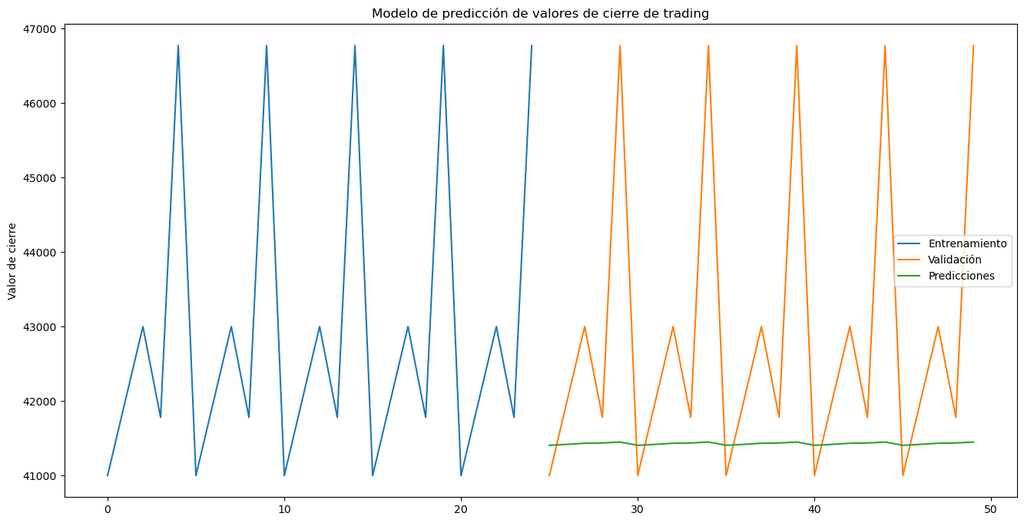

```python
import numpy as np
import pandas as pd
from sklearn.preprocessing import MinMaxScaler
from keras.models import Sequential
from keras.layers import Dense, LSTM

# Cargar los datos del archivo CSV
df = pd.read_csv('datos_trading.csv', encoding="utf-8")
print(df.head())

# Obtener los valores de cierre
close_data = df['Cierre'].values

# Escalar los datos
scaler = MinMaxScaler(feature_range=(0,1))
close_data = scaler.fit_transform(close_data.reshape(-1,1))

# Definir el tamaño de la ventana de tiempo y dividir los datos en entrenamiento y prueba
window_size = 20
train_size = int(len(close_data) * 0.5)
train_data = close_data[0:train_size,:]
test_data = close_data[train_size - window_size:,:]

# Crear las ventanas de tiempo
def create_windows(data, window_size):
    X = []
    y = []
    for i in range(window_size, len(data)):
        X.append(data[i-window_size:i,0])
        y.append(data[i,0])
    return np.array(X), np.array(y)

x_train, y_train = create_windows(train_data, window_size)
x_test, y_test = create_windows(test_data, window_size)

# Darle forma a los datos de entrada para la red LSTM
x_train = np.reshape(x_train, (x_train.shape[0], x_train.shape[1], 1))
x_test = np.reshape(x_test, (x_test.shape[0], x_test.shape[1], 1))

# Crear el modelo LSTM
model = Sequential()
model.add(LSTM(units=50, return_sequences=True, input_shape=(x_train.shape[1], 1)))
model.add(LSTM(units=50))
model.add(Dense(1))

# Compilar el modelo
model.compile(optimizer='adam', loss='mean_squared_error')

# Entrenar el modelo
model.fit(x_train, y_train, epochs=1, batch_size=1)

# Evaluar el modelo
model.evaluate(x_test, y_test)

# Hacer predicciones con el modelo
predictions = model.predict(x_test)
predictions = scaler.inverse_transform(predictions)

# Graficar las predicciones
import matplotlib.pyplot as plt

train = df[:train_size]
valid = df[train_size:]
valid['Predictions'] = predictions

plt.figure(figsize=(16,8))
plt.title('Modelo de predicción de valores de cierre de trading')
plt.ylabel('Valor de cierre')
plt.plot(train['Cierre'])
plt.plot(valid[['Cierre', 'Predictions']])
plt.legend(['Entrenamiento', 'Validación', 'Predicciones'])
plt.show()
```

```python
print(df.columns)
```

```
Index(['Cierre'], dtype='object')
```

```
       Fecha  Cierre
0 2023-01-01      31
1 2023-01-02      31
2 2023-01-03      72
3 2023-01-04      44
4 2023-01-05      43
```

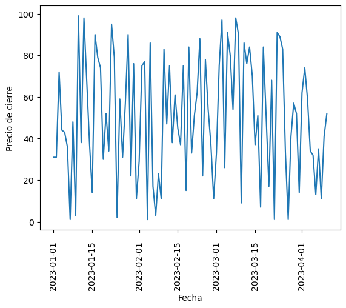

```python
import pandas as pd
import numpy as np
import matplotlib.pyplot as plt

# Crear 100 datos aleatorios
fechas = pd.date_range(start='2023-01-01', end='2023-04-10')
cierre = np.random.randint(100, size=(100))

# Crear un DataFrame con las fechas y el valor de cierre
df = pd.DataFrame({'Fecha': fechas, 'Cierre': cierre})

# Guardar el DataFrame como un archivo CSV
df.to_csv('datos2_trading.csv', index=False)

# Leer el archivo CSV
df = pd.read_csv('datos2_trading.csv')

# Convertir la columna de fecha al tipo datetime
df['Fecha'] = pd.to_datetime(df['Fecha'])

# Crear el gráfico
plt.plot(df['Fecha'], df['Cierre'])

# Etiquetar los ejes
plt.xlabel('Fecha')
plt.ylabel('Precio de cierre')
plt.xticks(rotation=90)
plt.tick_params(axis='x', which='major', pad=10)

# Mostrar el gráfico
print(df.head())
plt.show()
```

```
       Fecha  Cierre
0 2023-01-01       0
1 2023-01-02       1
2 2023-01-03       4
3 2023-01-04       9
4 2023-01-05      16
```

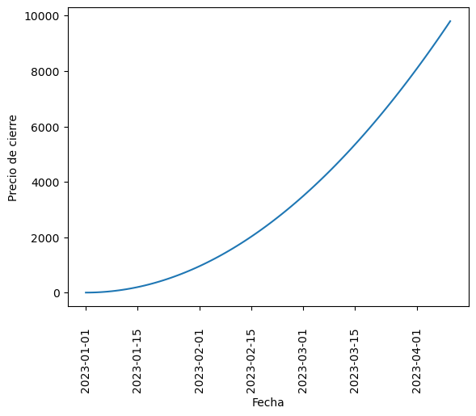

```python
import pandas as pd
import matplotlib.pyplot as plt

# crear datos de ejemplo
data = {'Fecha': pd.date_range(start='2023-01-01', periods=100),
        'Cierre': [i**2 for i in range(100)]}
df = pd.DataFrame(data)

# guardar datos en un archivo csv
df.to_csv('datos_trading3.csv', index=False)

# leer el archivo csv
df = pd.read_csv('datos_trading3.csv',header=0)

# convertir la columna 'Fecha' al tipo datetime
df['Fecha'] = pd.to_datetime(df['Fecha'])

# crear el gráfico
plt.plot(df['Fecha'], df['Cierre'])

# etiquetar los ejes
plt.xlabel('Fecha')
plt.ylabel('Precio de cierre')

# ajustar los ticks del eje x
plt.xticks(rotation=90)
plt.tick_params(axis='x', which='major', pad=15)
print(df.head())
# mostrar el gráfico
plt.show()
```

```
       Fecha  Cierre
0 2023-01-01       0
1 2023-01-02       1
2 2023-01-03       4
3 2023-01-04       9
4 2023-01-05      16
```

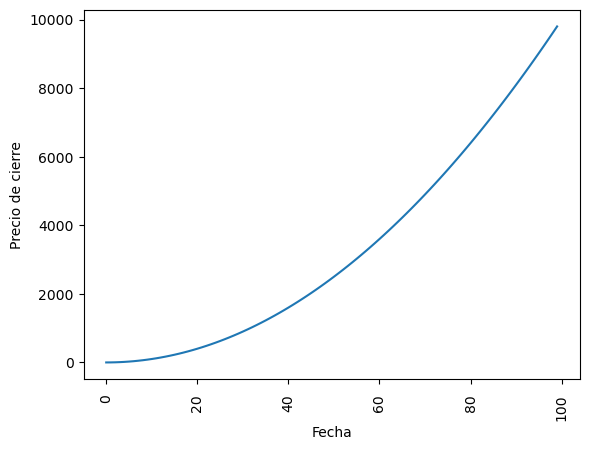

```python
import pandas as pd
import matplotlib.pyplot as plt

# crear el gráfico
plt.plot(df.index, df['Cierre'])

# etiquetar los ejes
plt.xlabel('Fecha')
plt.ylabel('Precio de cierre')
plt.xticks(rotation=90)
plt.tick_params(axis='x', which='major', pad=7)
print(df.head())

# mostrar el gráfico
plt.show()
```

```python
import pandas as pd

# Leer el archivo CSV
df = pd.read_csv('datos_trading3.csv')

# Calcular el promedio de cada columna
promedios = df.mean()
print(promedios)
```

```
Cierre    3283.5
dtype: float64
```

```python
import pandas as pd

# Leer archivo Excel
df = pd.read_excel('datos_trading4.xlsx')

# Imprimir primeras filas del DataFrame
print(df.head())
```

```
       Fecha  Cierre  Unnamed: 2    3283.5 328350
0 2023-01-01       0         NaN  PROMEDIO   SUMA
1 2023-01-02       1         NaN       NaN    NaN
2 2023-01-03       4         NaN       NaN    NaN
3 2023-01-04       9         NaN       NaN    NaN
4 2023-01-05      16         NaN       NaN    NaN
```

```python
import pandas as pd
df = pd.read_excel("ejemplos.xlsx")
print(df.head())
```

```
   ID Nucleótido 1 Nucleótido 2 Nucleótido 3 Nucleótido 4 Nucleótido 5  \
0   1            G            A            T            G            T
1   2            A            T            C            T            A
2   3            T            A            T            G            G
3   4            C            C            C            T            C
4   5            A            T            C            C            T

  Nucleótido 6 Nucleótido 7 Nucleótido 8 Nucleótido 9  ... Nucleótido 11  \
0            G            T            A            T  ...             T
1            G            C            C            C  ...             A
2            A            G            T            G  ...             C
3            T            T            G            A  ...             G
4            C            G            C            A  ...             C

  Nucleótido 12 Nucleótido 13 Nucleótido 14 Nucleótido 15 Nucleótido 16  \
0             G             A             T             C             A
1             T             G             C             G             G
2             A             C             A             A             T
3             C             A             T             C             C
4             G             T             C             T             T

  Nucleótido 17 Nucleótido 18 Nucleótido 19 Nucleótido 20
0             T             G             A             T
1             C             C             T             A
2             G             T             G             C
3             C             A             T             T
4             C             C             C             G

[5 rows x 21 columns]
```

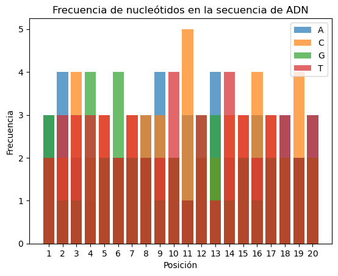

```python
import matplotlib.pyplot as plt

# Creamos un diccionario para almacenar la frecuencia de cada nucleótido
nucleotidos = {
    "A": [0]*20,
    "C": [0]*20,
    "G": [0]*20,
    "T": [0]*20
}

# Recorremos el DataFrame y contamos la frecuencia de cada nucleótido en cada posición
for i in range(20):
    for nucleotido in nucleotidos.keys():
        nucleotidos[nucleotido][i] = df[f"Nucleótido {i+1}"].value_counts()[nucleotido].astype(int)

# Creamos un gráfico de barras para mostrar la frecuencia de cada nucleótido en cada posición
for nucleotido in nucleotidos.keys():
    plt.bar(range(1, 21), nucleotidos[nucleotido], label=nucleotido, alpha=0.7)

# Configuramos el gráfico
plt.xticks(range(1, 21))
plt.xlabel("Posición")
plt.ylabel("Frecuencia")
plt.title("Frecuencia de nucleótidos en la secuencia de ADN")
plt.legend()

# Mostramos el gráfico
plt.show()
```

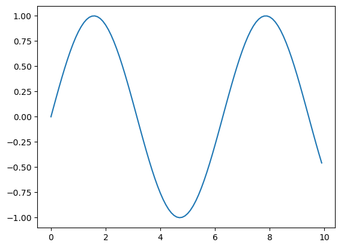

```python
import matplotlib.pyplot as plt
import numpy as np

# Crear datos de ejemplo
x = np.arange(0, 10, 0.1)
y = np.sin(x)

# Crear el gráfico
plt.plot(x, y)

# Guardar el gráfico como una imagen
plt.savefig("mi_grafico.png")
```

CON ESTE COMANDO PODEMOS GUARDAR NUESTRAS GRÁFICAS COMO IMAGENES EN NUESTRAS COMPUTADORAS

**MUCHAS GRACIAS SOMOS AEON MERX , METODOLOGÍA B.I.O.S**